# Assignment 2

Gracie White and Chase Brewster

4/25/2019

This homework asks you to examine the possible distributional effects of a (mostly real) proposal to raise the gas tax in France. The overall questions are: (1) What will be the distributional effects of the tax increase? (2) How much revenue will be generated for infrastructure repairs? (3) By how much will environmental damage be reduced and who will benefit? (4) What is the role of electric vehicle demand?

1. Consumers can be separated into two income groups: “High” and “Low”. The data set provides price (in $) and quantity (in gallons) estimates of demand per day for the two groups. Run regressions to estimate the demand curves for “High” and “Low” income consumers.
2. Initially, there is no gas tax.
3. The current gas price (without any taxes) is $5.00/gal.
4. The marginal cost of producing a gallon of gasoline is linear and has priceintercept of 0. For the purposes of this exercise, you can assume that France is self-contained in supply and demand (you don’t need to worry about global markets).
5. Consuming each gallon of gasoline creates an environmental and health externality in France of approximately $2.00.

1. What is the aggregate daily demand curve for gasoline in France? What is the supply curve for gasoline? What is the “benefit” to consumers under the status quo? What is the “benefit” to producers under the status quo? What is the environmental cost under the status quo?

```r
#problem 1:

#ok so first creating 2 linear models for each income group.

high_lm <- lm(Price_Dollars ~ Q_High_Gallons_per_Day, data = gas)
high_lm
```

```
##
## Call:
## lm(formula = Price_Dollars ~ Q_High_Gallons_per_Day, data = gas)
##
## Coefficients:
##            (Intercept)  Q_High_Gallons_per_Day
##             23.3914418              -0.0001297
```

```r
high_intercept <- 23.3914418
high_slope <- -0.0001297

#high price = 23.3914418 + -0.0001297(Q)


low_lm <- lm(Price_Dollars ~ Q_Low_Gallons_per_Day, data = gas)
low_lm
```

```
##
## Call:
## lm(formula = Price_Dollars ~ Q_Low_Gallons_per_Day, data = gas)
##
## Coefficients:
##           (Intercept)  Q_Low_Gallons_per_Day
##            21.9908534             -0.0001355
```

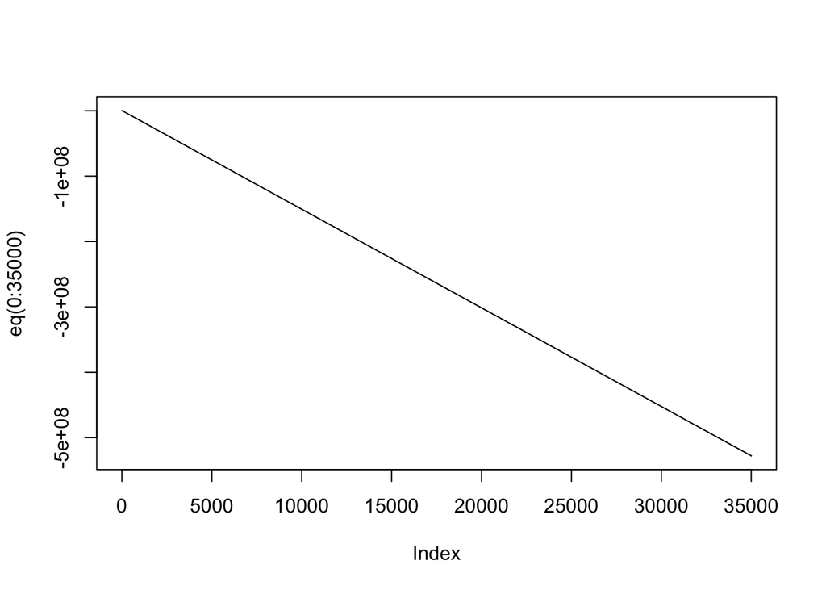

```r
low_intercept = 21.9908534
low_slope = -0.0001355

#low price = 21.9908534 + -0.0001355(Q)

#aggregate price, solved both equations for q, then added

# DEMAND CURVE
#Qag = 342644.4818 - 15090.2P

Qag_intercept <- 342644.4818
Qag_slope <- -15090.2

#Demand Curve Plot
eq <- function(x){342644.4818 - 15090.2*x}
plot(eq(0:35000), type = 'l')
```